# PA1_template

PNS

September 16, 2015

## Loading and preprocessing the data

```r
library(knitr)
library(datasets)
library(ggplot2)
library (scales)
library(Hmisc)
if(!file.exists("activity.csv"))
{unzip("activity.zip")}

activity_dfm <- read.csv("activity.csv")
```

## What is mean total number of steps taken per day?

1. Calculate the total number of steps taken per day
2. If you do not understand the difference between a histogram and a barplot, research the difference between them. Make a histogram of the total number of steps taken each day
3. Calculate and report the mean and median of the total number of steps taken per day

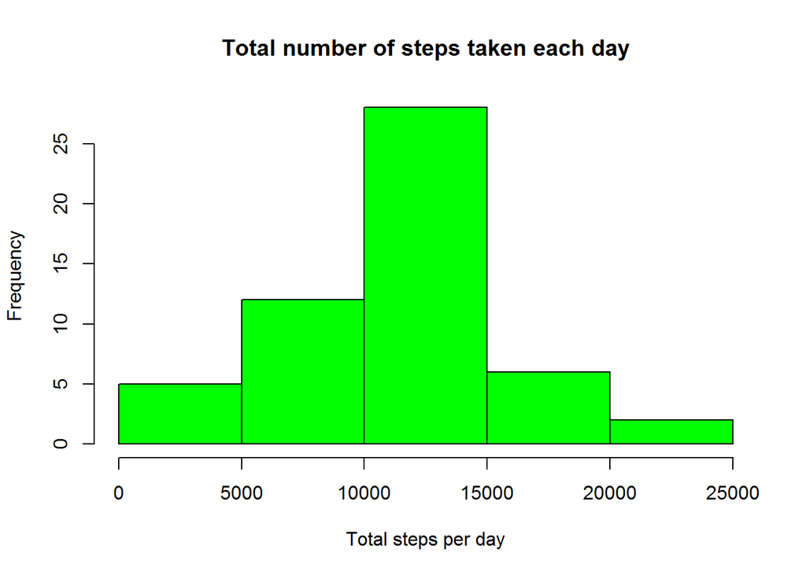

```r
stepsperday <-aggregate(steps ~ date,activity_dfm,sum)

hist(stepsperday$steps, main = ("Total number of steps taken each day"),col="green", xlab="Total steps per day")
```

```r
steps_mean <-mean(stepsperday$steps)

paste("Steps Mean is :", steps_mean)
```

```
## [1] "Steps Mean is : 10766.1886792453"
```

```r
steps_median <-median(stepsperday$steps)

paste("Steps Median is :", steps_median)
```

```
## [1] "Steps Median is : 10765"
```

## What is the average daily activity pattern?

1. Make a time series plot (i.e. type = “l”) of the 5-minute interval (x-axis) and the average number of steps taken, averaged across all days (y-axis)
2. Which 5-minute interval, on average across all the days in the dataset, contains the maximum number of steps?

```r
ave_stepsper_interval <- aggregate(x=list(meansteps=activity_dfm$steps),by=list(interval=activity_dfm$interval), FUN=mean, na.rm=TRUE)

maxsteps <- which.max(ave_stepsper_interval$meansteps)
paste("Max number of steps per day is :", maxsteps)
```

[output not shown]

```r
maxtime <- gsub("([0-9]{1,2})([0-9]{2})", "\\1:\\2", ave_stepsper_interval[maxsteps,'interval'])
paste("Max interval is at  :", maxtime)
```

```
## [1] "Max interval is at  : 8:35"
```

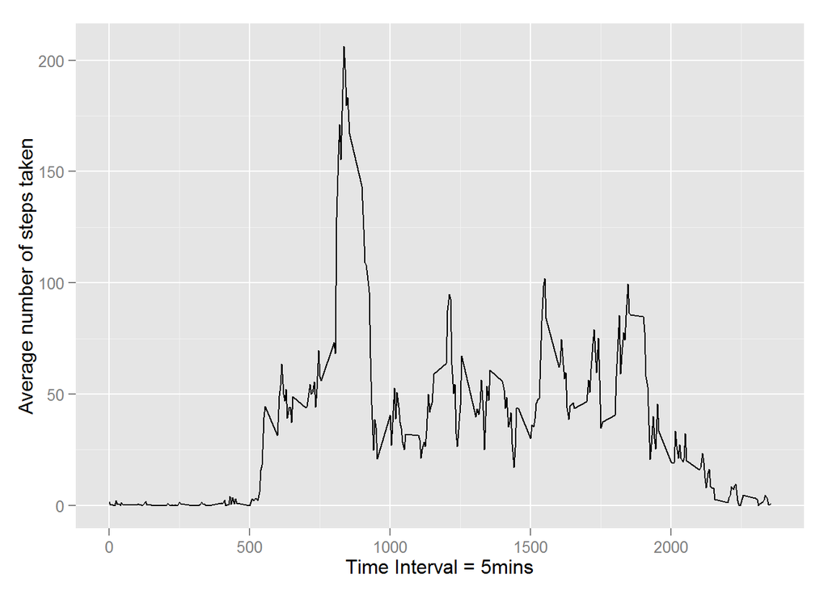

```r
ggplot(data=ave_stepsper_interval, aes(x=interval, y=meansteps)) + geom_line() + xlab("Time Interval = 5mins") + ylab("Average number of steps taken")
```